# Frax

M. Newbery

03/06/2020

Markdown runs in chunks, makes it easier to compartmentalise operations and structure script. Knitting the document with knitr outputs word document

```r
knitr::opts_chunk$set(echo = TRUE, fig.width=8, fig.height=6)

library(here)
library(dplyr)
library(ggplot2)
library(mgcv)
library(readxl)
library(stringr)
library(tidyr)
library(bayesplot)
library(rstan)
library(brms)
library(tidybayes)
library(RColorBrewer)
library(car)
###### Some helper functions courtesy of Michael Bedward #####


#These options help Stan run faster (Stan is the machinery under the hood of brms):

rstan_options(auto_write = TRUE)
options(mc.cores = parallel::detectCores())

# Make sure the scales package is available (it should be if ggplot is installed)
requireNamespace("scales")

# Default graph theme - white background
theme_set( theme_bw() )

set.seed(42)


# Set to TRUE to force models to be refitted
REFIT_MODELS <- FALSE


# Create a folder for fitted models if one does not already exist
FittedModelsPath <- here("fitted_models")
if (!dir.exists(FittedModelsPath)) {
  dir.create(FittedModelsPath)
}


# Load brms if it is installed (requires Stan software and the rstan package).
# If not installed, HAS_BRMS will be set to FALSE.
HAS_BRMS <- suppressWarnings(
  require("brms", quietly = TRUE)
)


# Save a graph to a PDF file
gg_pdf <- function(plot, filename, size = pagesize("A4", "landscape", "cm")) {

  if (!inherits(size, "pagesize")) stop("The size argument should be a pagesize (list) object")

  ggsave(
    filename,
    plot,
    width = size$width,
    height = size$height,
    units = size$units)
}


# Calculate highest posterior density interval for a vector of values (e.g. calculate credible intervals)
hpdi.vec <- function (x, prob = 0.95) {
  n <- length(x)
  if (n <= 1) stop("x must have more than 1 element")
  x <- sort(x)

  gap <- max(1, min(n - 1, round(n * prob)))
  init <- 1:(n - gap)

  inds <- which.min(x[init + gap] - x[init])

  out <- c(lower = x[inds], upper = x[inds + gap])
  out
}
```

creat dataframe and view column names

```r
dat.pre1 <- read.csv("frax_mort.csv")

dat.pre1
```

| Site | Severity | DBH | Circumference..m. | Mortality | Burn.Height..m. |
| --- | --- | --- | --- | --- | --- |
| Mod4 | Mod | 9.549297 | 0.30 | 2 | 3.0 |
| Mod4 | Mod | 10.185916 | 0.32 | 2 | 3.0 |
| Mod4 | Mod | 10.822536 | 0.34 | 2 | 7.0 |
| Low1 | Low | 11.777466 | 0.37 | 2 | 7.0 |
| Mod4 | Mod | 12.095776 | 0.38 | 2 | 1.5 |
| Mod4 | Mod | 12.732395 | 0.40 | 2 | 1.0 |
| Ext2 | Ext | 12.732395 | 0.40 | 2 | 5.0 |
| Ext2 | Ext | 13.369015 | 0.42 | 2 | 6.0 |
| Low1 | Low | 13.687325 | 0.43 | 2 | 15.0 |
| Ext1 | Ext | 13.687325 | 0.43 | 2 | 5.0 |

[output cut: 395 more lines]

select variables of interest and rename to whatever you want. Shorter is better

```r
dat.pre1 <- dat.pre1 %>%
  select(site = "Site",
         sev = "Severity",
         dbh = "DBH",
         loc = "Mortality",)


dat.pre1
```

| site | sev | dbh | loc |
| --- | --- | --- | --- |
| Mod4 | Mod | 9.549297 | 2 |
| Mod4 | Mod | 10.185916 | 2 |
| Mod4 | Mod | 10.822536 | 2 |
| Low1 | Low | 11.777466 | 2 |
| Mod4 | Mod | 12.095776 | 2 |
| Mod4 | Mod | 12.732395 | 2 |
| Ext2 | Ext | 12.732395 | 2 |
| Ext2 | Ext | 13.369015 | 2 |
| Low1 | Low | 13.687325 | 2 |
| Ext1 | Ext | 13.687325 | 2 |

[output cut: 395 more lines]

quick way to check what levels are in factors

```r
dat.pre1 %>%
  distinct(sev, loc, site)
```

| site | sev | loc |
| --- | --- | --- |
| Mod4 | Mod | 2 |
| Low1 | Low | 2 |
| Ext2 | Ext | 2 |
| Ext1 | Ext | 2 |
| Ext3 | Ext | 2 |
| Ext4 | Ext | 2 |
| Low2 | Low | 1 |
| Low2 | Low | 2 |
| Mod1 | Mod | 2 |
| Mod4 | Mod | 1 |

[output cut: 15 more lines]

```r
dat.frax2 <- dat.pre1%>%
  mutate(sev = factor(sev, levels = c("Low",     "Mod",     "Ext"),
                           labels = c("Low",     "Mod",     "High"))) %>%

    mutate(loc = factor(loc, levels = c("1", "2"),
                          labels = c("Alive", "Dead")))
```

## round dbh values to assist with modelling later. This is acceptable enough

```r
dat.frax2$dbh <- round(dat.frax2$dbh, digits = 1)
```

Check for missing values

```r
colSums( is.na(dat.frax2) )
```

```
## site  sev  dbh  loc
##    0    0    0    0
```

There are no missing values

Now a quick tabular look at the data

```r
with(dat.frax2, table(sev, loc))
```

```
##       loc
## sev    Alive Dead
##   Low     70   41
##   Mod     31   86
##   High     0  177
```

```r
with(dat.frax2, table(loc, sev))
```

```
##        sev
## loc     Low Mod High
##   Alive  70  31    0
##   Dead   41  86  177
```

overall summary of data

```r
summary(dat.frax2)
```

```
##       site       sev           dbh            loc
##  Ext2   : 58   Low :111   Min.   :  9.50   Alive:101
##  Ext1   : 47   Mod :117   1st Qu.: 23.60   Dead :304
##  Mod4   : 38   High:177   Median : 38.20
##  Ext4   : 34              Mean   : 42.53
##  Low1   : 34              3rd Qu.: 57.30
##  Mod1   : 25              Max.   :136.90
##  (Other):169
```

have a look at dbh relationship with resprouting location

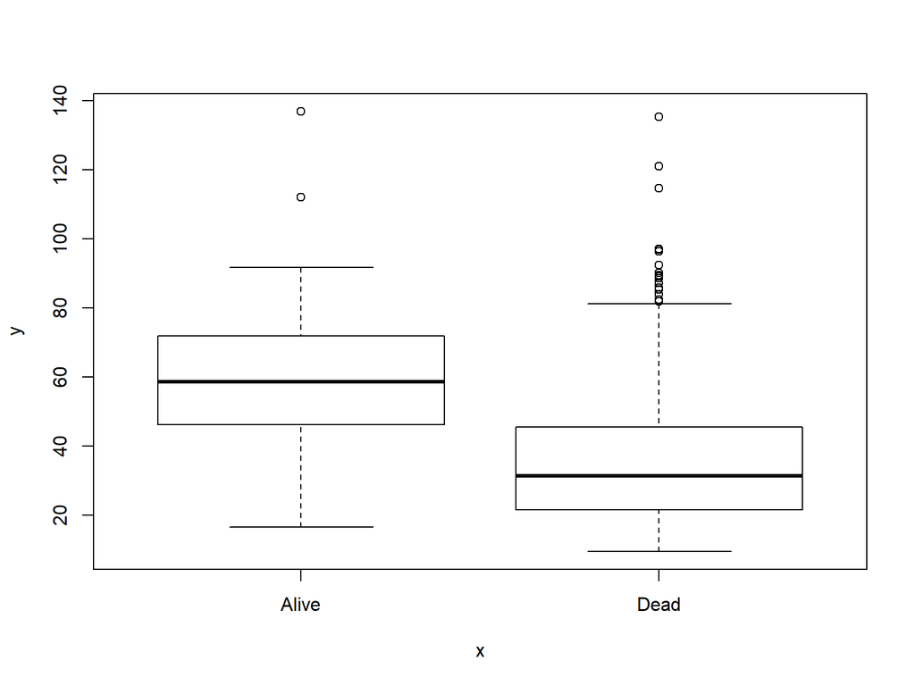

```r
plot(dat.frax2$loc, dat.frax2$dbh)
```

This is the expected relationship

Heres a more informative look at the data

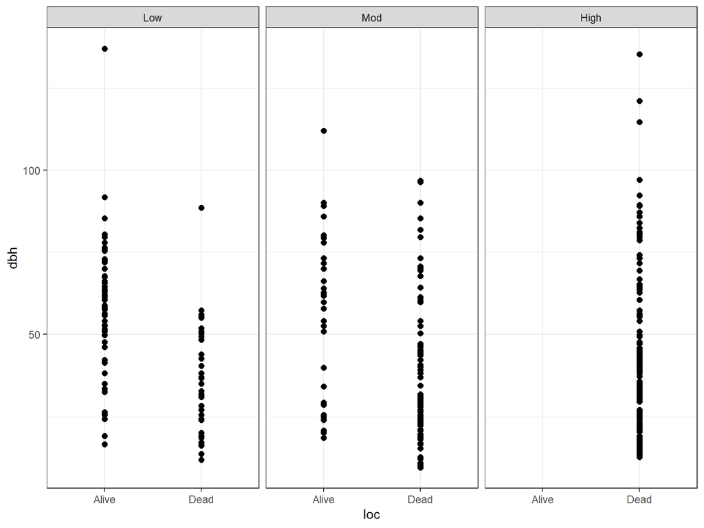

```r
ggplot(data = dat.frax2, aes(x = loc)) +

  geom_point(aes(y = dbh),
             position = position_dodge(width = 0.4),
             size = 2) +

  scale_color_brewer(palette = "Spectral") +

  facet_grid(~sev)
```

### model code

```r
library(future)
plan(multiprocess)
model.brms.frax <- brm(
    loc ~ sev + dbh + (1 | site),
  data = dat.frax2,
  family = bernoulli(),
  chains = 4,
  warmup = 2000,
  iter = 10000,
  control = list(adapt_delta = 0.99,
                 max_treedepth = 12))
plan(sequential)



summary(model.brms.frax)
```

```
##  Family: bernoulli
##   Links: mu = logit
## Formula: loc ~ sev + dbh + (1 | site)
##    Data: dat.frax2 (Number of observations: 405)
## Samples: 4 chains, each with iter = 10000; warmup = 2000; thin = 1;
##          total post-warmup samples = 32000
##
## Group-Level Effects:
## ~site (Number of levels: 15)
##               Estimate Est.Error l-95% CI u-95% CI Rhat Bulk_ESS Tail_ESS
## sd(Intercept)     0.98      0.43     0.32     2.00 1.00     8071     9075
##
## Population-Level Effects:
##           Estimate Est.Error l-95% CI u-95% CI Rhat Bulk_ESS Tail_ESS
## Intercept     1.86      0.69     0.51     3.25 1.00    16212    17161
## sevMod        1.87      0.79     0.36     3.52 1.00    10561    13667
## sevHigh      13.84      8.43     6.31    34.96 1.00     8279     4749
## dbh          -0.06      0.01    -0.08    -0.04 1.00    25118    21115
##
## Samples were drawn using sampling(NUTS). For each parameter, Bulk_ESS
## and Tail_ESS are effective sample size measures, and Rhat is the potential
## scale reduction factor on split chains (at convergence, Rhat = 1).
```

Model summary

```r
  summary(model.brms.frax)
```

```
##  Family: bernoulli
##   Links: mu = logit
## Formula: loc ~ sev + dbh + (1 | site)
##    Data: dat.frax2 (Number of observations: 405)
## Samples: 4 chains, each with iter = 10000; warmup = 2000; thin = 1;
##          total post-warmup samples = 32000
##
## Group-Level Effects:
## ~site (Number of levels: 15)
##               Estimate Est.Error l-95% CI u-95% CI Rhat Bulk_ESS Tail_ESS
## sd(Intercept)     0.98      0.43     0.32     2.00 1.00     8071     9075
##
## Population-Level Effects:
##           Estimate Est.Error l-95% CI u-95% CI Rhat Bulk_ESS Tail_ESS
## Intercept     1.86      0.69     0.51     3.25 1.00    16212    17161
## sevMod        1.87      0.79     0.36     3.52 1.00    10561    13667
## sevHigh      13.84      8.43     6.31    34.96 1.00     8279     4749
## dbh          -0.06      0.01    -0.08    -0.04 1.00    25118    21115
##
## Samples were drawn using sampling(NUTS). For each parameter, Bulk_ESS
## and Tail_ESS are effective sample size measures, and Rhat is the potential
## scale reduction factor on split chains (at convergence, Rhat = 1).
```

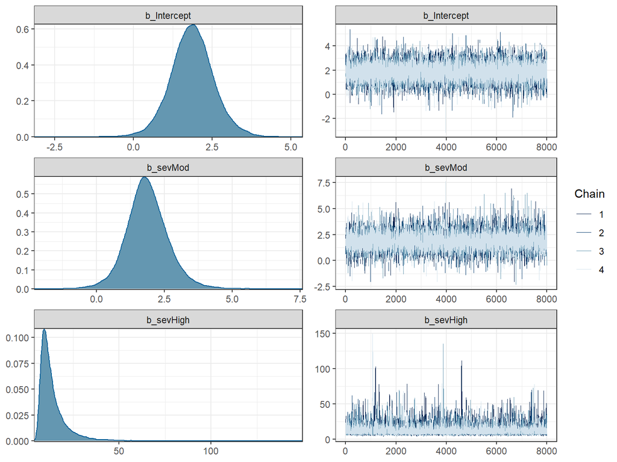

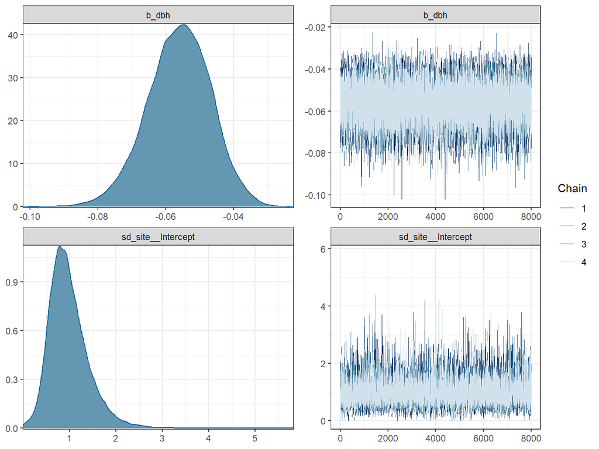

```r
if (HAS_BRMS) {
  plot(model.brms.frax, N=3, ask = FALSE, newpage = FALSE)
}
```

### predictions

```r
### create all unique combinations of variables (use expand.grid when cont. vars.)

post.frax <- expand.grid(
  dbh = seq(12, 100, 1),
  sev = levels(dat.frax2$sev)) %>%


### add fitted draws - this adds predictions to the data in from the posterior disturbution produced by the model.

  tidybayes::add_fitted_draws(model.brms.frax, n = 3000, re_formula = NA) %>%
  ungroup() %>%

  select(iter=.draw, dbh, sev, Probability = .value)
```

```r
effect2 <- post.frax %>%

  filter(dbh >= 12 & dbh <= 100) %>%
tidyr::spread(sev, Probability)


diff2 <- effect2 %>%

  mutate(diff_Extreme = High,
         diff_Low = Low,
         diff_Moderate = Mod) %>%

  select(dbh, starts_with("diff"))

# convert to long format for ggplot
dat.gg2 <- diff2 %>%
  tidyr::gather(severity, diff, -dbh) %>%
  mutate(severity = factor(str_replace(severity, "diff_", ""))) %>%
  mutate(severity = factor(str_replace(severity, "_", "/")))


## main summary stats to be used for plotting


## for severity plot
x.stats2 <- dat.gg2 %>%
  group_by(dbh, severity) %>%
    summarize(mid = median(diff),
            lwr95 = hpdi.vec(diff, 0.95)[1],
            upr95 = hpdi.vec(diff, 0.95)[2],
            lwr50 = hpdi.vec(diff, 0.50)[1],
            upr50 = hpdi.vec(diff, 0.50)[2])
```

## plot

```r
## theme parameters can be adjusted to suit your needs

library(ggthemes)
```

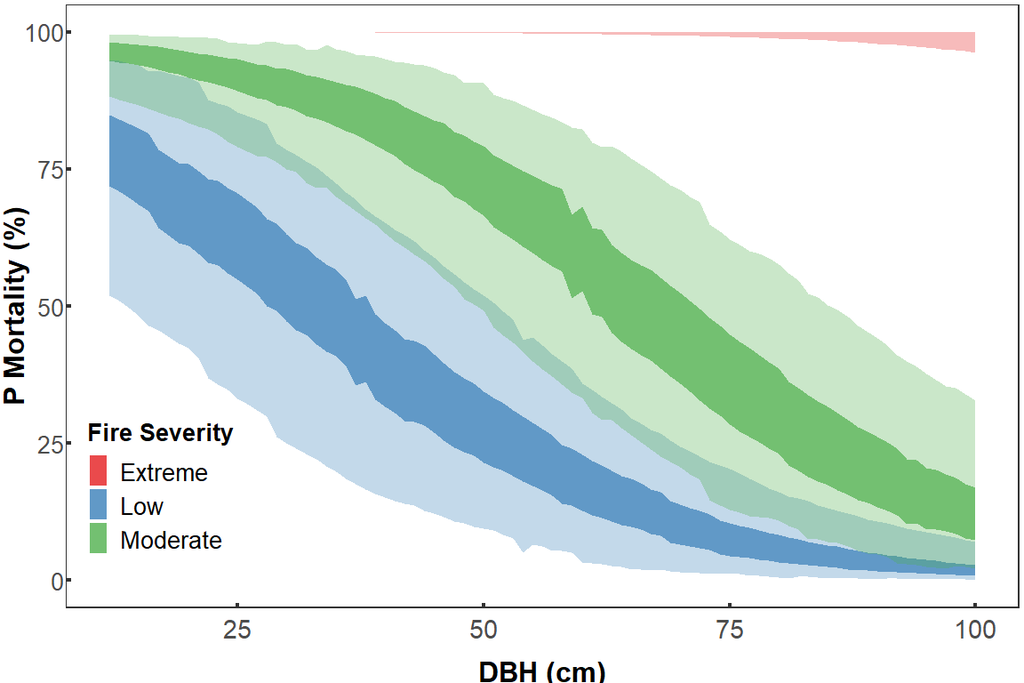

```r
My_Theme = theme(
  plot.title = element_text(size = 12, face = "bold", hjust = 0.5),
  axis.title.y = element_text(size = 12, face = "bold", vjust = 1.5),
  axis.text.y = element_text(size = 10, margin = unit(c(0.1, 0.1, 0.1, -0.2), "cm")),
  axis.text.x = element_text(size = 11, vjust = 0, margin = unit(c(0.15, 0.1, 0.1, 0.1), "cm")),
  axis.title.x = element_text(size = 12, face = "bold", vjust = -0.6),
  strip.text.x = element_text(size = 11),
  strip.text.y = element_text(size = 11),
  strip.text = element_text(size = 11),
  strip.background = element_blank(),
  panel.background = element_blank(),
  strip.placement = "inside",
  axis.ticks.length = unit(-0.07, "cm"),
  axis.ticks = element_line(size = 0.8),
  panel.grid.minor.x = element_blank(),
  panel.grid.major.x = element_blank(),
  panel.grid.minor.y = element_blank(),
  panel.grid.major.y = element_blank(),
  legend.position = c(0.1,0.2),
  legend.title = element_text(size = 10, hjust = 0.6, face = "bold"),
  legend.text = element_text(size = 10),
  legend.key.width = unit(0.3, "cm"),
  legend.key.height = unit(0.5, "cm"),
  legend.background = element_blank(),
  plot.margin = unit(c(2, 2, 2, 2), "pt"))


frax.sev.plot <- ggplot(data = dat.gg2, aes (x = dbh)) +

 My_Theme +

  geom_ribbon(data = x.stats2, aes(ymin = lwr50, ymax = upr50, fill = severity), alpha = 0.7) +
  geom_ribbon(data = x.stats2, aes(ymin = lwr95, ymax = upr95, fill = severity), alpha = 0.3) +



  labs(y = "P Mortality (%)", x = "DBH (cm)", fill = "Fire Severity") +


  scale_y_continuous(labels = scales::percent_format(suffix = "", accuracy = 1), limits = c(0, 1)) +

  scale_fill_brewer(palette = "Set1")


frax.sev.plot
```

Probability at different values of DBH

```r
means <- dat.gg2 %>%
  mutate(
    dbh = case_when(
         dbh >= 20 & dbh <= 25 ~ "20-25",
         dbh >= 25.1 & dbh <= 35 ~ "25-35",
         dbh >= 35.1 & dbh <= 45 ~ "35-45",
         dbh >= 45.1 & dbh <= 55 ~ "45-55",
         dbh >= 55.1 & dbh <= 80 ~ "55-80"))
         means <- means %>%
  group_by(dbh, severity) %>%
  summarize(prob = mean(diff))
knitr::kable(means, digits = 3)
```

| dbh | severity | prob |
| --- | --- | --- |
| 20-25 | Extreme | 1.000 |
| 20-25 | Low | 0.637 |
| 20-25 | Moderate | 0.910 |
| 25-35 | Extreme | 1.000 |
| 25-35 | Low | 0.537 |
| 25-35 | Moderate | 0.869 |
| 35-45 | Extreme | 1.000 |
| 35-45 | Low | 0.408 |
| 35-45 | Moderate | 0.797 |
| 45-55 | Extreme | 0.999 |
| 45-55 | Low | 0.289 |
| 45-55 | Moderate | 0.699 |
| 55-80 | Extreme | 0.999 |
| 55-80 | Low | 0.145 |
| 55-80 | Moderate | 0.482 |
| NA | Extreme | 0.997 |
| NA | Low | 0.239 |
| NA | Moderate | 0.431 |

```r
means <- dat.gg2 %>%
  mutate(
    dbh = case_when(
         dbh >= 20 & dbh <= 25 ~ "20-25",
         dbh >= 25.1 & dbh <= 35 ~ "25-35",
         dbh >= 35.1 & dbh <= 45 ~ "35-45",
         dbh >= 45.1 & dbh <= 55 ~ "45-55",
         dbh >= 55.1 & dbh <= 80 ~ "55-80"))
```

## difference calculations.

```r
effect1.a.avg1 <- post.frax %>%


  filter(dbh >= 25 & dbh <= 26) %>%

  tidyr::spread(sev, Probability)



effect1.a.lrg1 <- post.frax %>%


  filter(dbh >= 50 & dbh <= 51) %>%


  tidyr::spread(sev, Probability)
```

```r
## average sized trees Low and High
diffs1.a.avg <- effect1.a.avg1 %>%

  mutate(diff_sev = (Low - High)) %>%

  select(diff_sev, starts_with("diff"))

## average sized trees Low and Mod
diffs2.a.avg <- effect1.a.avg1 %>%

  mutate(diff_sev = (Low - Mod)) %>%

  select(diff_sev, starts_with("diff"))

## averaged sized trees mod and high
diffs3.a.avg <- effect1.a.avg1 %>%

  mutate(diff_sev = (Mod - High)) %>%

  select(diff_sev, starts_with("diff"))

## larger trees Low - high

diffs1.a.lrg1 <- effect1.a.lrg1 %>%

  mutate(diff_sev = (Low - High)) %>%

  select(diff_sev, starts_with("diff"))

## larger trees low - mod

diffs2.a.lrg1 <- effect1.a.lrg1 %>%

  mutate(diff_sev = (Low - Mod)) %>%

  select(diff_sev, starts_with("diff"))

## larger trees mod - high

diffs3.a.lrg1 <- effect1.a.lrg1 %>%

  mutate(diff_sev = (Mod - High)) %>%

  select(diff_sev, starts_with("diff"))
```

```r
# convert to long format for ggplot


### average sized trees low - high
dat.gg1.a.avg1 <- diffs1.a.avg %>%
  tidyr::gather(var, diff) %>%
  mutate(var = factor(str_replace(var, "diff_", ""))) %>%
  mutate(var = factor(str_replace(var, "_", "/")))

x.stats1.a.avg1 <- dat.gg1.a.avg1 %>%
  group_by(var) %>%
    summarize(mid = median(diff),
            lwr95 = hpdi.vec(diff, 0.95)[1],
            upr95 = hpdi.vec(diff, 0.95)[2],
            lwr50 = hpdi.vec(diff, 0.50)[1],
            upr50 = hpdi.vec(diff, 0.50)[2])

## averaged sized trees low - mod

dat.gg2.a.avg1 <- diffs2.a.avg %>%
  tidyr::gather(var, diff) %>%
  mutate(var = factor(str_replace(var, "diff_", ""))) %>%
  mutate(var = factor(str_replace(var, "_", "/")))

x.stats2.a.avg1 <- dat.gg2.a.avg1 %>%
  group_by(var) %>%
    summarize(mid = median(diff),
            lwr95 = hpdi.vec(diff, 0.95)[1],
            upr95 = hpdi.vec(diff, 0.95)[2],
            lwr50 = hpdi.vec(diff, 0.50)[1],
            upr50 = hpdi.vec(diff, 0.50)[2])

## averaged sized trees mod - high

dat.gg3.a.avg1 <- diffs3.a.avg %>%
  tidyr::gather(var, diff) %>%
  mutate(var = factor(str_replace(var, "diff_", ""))) %>%
  mutate(var = factor(str_replace(var, "_", "/")))

x.stats3.a.avg1 <- dat.gg1.a.avg1 %>%
  group_by(var) %>%
    summarize(mid = median(diff),
            lwr95 = hpdi.vec(diff, 0.95)[1],
            upr95 = hpdi.vec(diff, 0.95)[2],
            lwr50 = hpdi.vec(diff, 0.50)[1],
            upr50 = hpdi.vec(diff, 0.50)[2])


## larger trees Low - High
dat.gg1.a.lrg1 <- diffs1.a.lrg1 %>%
  tidyr::gather(var, diff) %>%
  mutate(var = factor(str_replace(var, "diff_", ""))) %>%
  mutate(var = factor(str_replace(var, "_", "/")))


x.stats1.a.lrg1 <- dat.gg1.a.lrg1 %>%
  group_by(var) %>%
    summarize(mid = median(diff),
            lwr95 = hpdi.vec(diff, 0.95)[1],
            upr95 = hpdi.vec(diff, 0.95)[2],
            lwr50 = hpdi.vec(diff, 0.50)[1],
            upr50 = hpdi.vec(diff, 0.50)[2])

## larger trees Low - Mod
dat.gg2.a.lrg1 <- diffs2.a.lrg1 %>%
  tidyr::gather(var, diff) %>%
  mutate(var = factor(str_replace(var, "diff_", ""))) %>%
  mutate(var = factor(str_replace(var, "_", "/")))


x.stats2.a.lrg1 <- dat.gg1.a.lrg1 %>%
  group_by(var) %>%
    summarize(mid = median(diff),
            lwr95 = hpdi.vec(diff, 0.95)[1],
            upr95 = hpdi.vec(diff, 0.95)[2],
            lwr50 = hpdi.vec(diff, 0.50)[1],
            upr50 = hpdi.vec(diff, 0.50)[2])

## larger trees Mod - High
dat.gg3.a.lrg1 <- diffs3.a.lrg1 %>%
  tidyr::gather(var, diff) %>%
  mutate(var = factor(str_replace(var, "diff_", ""))) %>%
  mutate(var = factor(str_replace(var, "_", "/")))


x.stats3.a.lrg1 <- dat.gg1.a.lrg1 %>%
  group_by(var) %>%
    summarize(mid = median(diff),
            lwr95 = hpdi.vec(diff, 0.95)[1],
            upr95 = hpdi.vec(diff, 0.95)[2],
            lwr50 = hpdi.vec(diff, 0.50)[1],
            upr50 = hpdi.vec(diff, 0.50)[2])
```

### difference for average sized trees Low - High

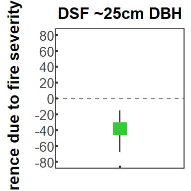

```r
My_Theme = theme(
  plot.title = element_text(size = 12, face = "bold", hjust = 0.5),
  axis.title.y = element_text(size = 12, face = "bold"),
  axis.text.y = element_text(size = 10, margin = unit(c(0.1, 0.1, 0.1, -0.2), "cm")),
  axis.text.x = element_blank(),
  axis.title.x = element_text(size = 12, face = "bold", vjust = -0.6),
  strip.text.x = element_text(size = 11),
  strip.text.y = element_text(size = 11),
  strip.text = element_text(size = 11),
  strip.background = element_blank(),
  panel.background = element_blank(),
  strip.placement = "inside",
  axis.ticks.length = unit(-0.07, "cm"),
  axis.ticks = element_line(size = 0.8),
  panel.grid.minor.x = element_blank(),
  panel.grid.major.x = element_blank(),
  panel.grid.minor.y = element_blank(),
  panel.grid.major.y = element_blank(),
  legend.position = "bottom",
  legend.title = element_text(size = 9, hjust = 0.6, face = "bold"),
  legend.text = element_text(size = 9),
  legend.key.width = unit(0.3, "cm"),
  legend.key.height = unit(0.5, "cm"),
  legend.background = element_blank(),
  plot.margin = unit(c(5, 5, 5, 5), "pt"))


diff.avg.frax1 <- ggplot(data = x.stats1.a.avg1, aes(x = var)) +

  My_Theme +

  geom_linerange(aes(ymin = lwr95, ymax = upr95),
               size = 0.5, position = position_dodge(width = 0.6)) +

  geom_linerange(aes(ymin = lwr50, ymax = upr50),
               size = 5.0, show.legend = FALSE, position = position_dodge(width = 0.6), col = "limegreen") +


  labs(x = "", y = "Difference due to fire severity (%)\n", title = "DSF ~25cm DBH") +


  geom_hline(yintercept = 0, linetype = "dashed", alpha = 0.5) +


  scale_y_continuous(labels = scales::percent_format(suffix = "", accuracy = 1), limits = c(-0.8, 0.8), breaks = c(-0.8, -0.6, -0.4, -0.2, 0, 0.2, 0.4, 0.6, 0.8)) +
  coord_cartesian(ylim=c(-0.8, 0.8))

diff.avg.frax1
```

## Change in difference for 25 cm trees

```r
dat.gg1.a.avg1 %>%
  group_by(var) %>%
  summarize(prob = mean(diff))
```

|  | var | prob |
| --- | --- | --- |
| 1 | sev | -0.3994117 |

Summary of magnitude of differences based on 50% and 95% highest posterior density intervals for 25cm trees

```r
x.stats1.a.avg1
```

|  | var | mid | lwr95 | upr95 | lwr50 | upr50 |
| --- | --- | --- | --- | --- | --- | --- |
| 1 | sev | -0.389769 | -0.6761392 | -0.1498418 | -0.4614811 | -0.3036654 |

### difference for average sized trees Low - Mod

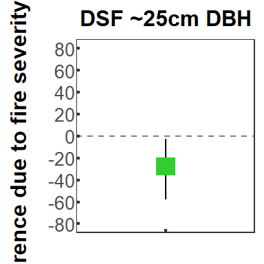

```r
My_Theme = theme(
  plot.title = element_text(size = 12, face = "bold", hjust = 0.5),
  axis.title.y = element_text(size = 12, face = "bold"),
  axis.text.y = element_text(size = 10, margin = unit(c(0.1, 0.1, 0.1, -0.2), "cm")),
  axis.text.x = element_blank(),
  axis.title.x = element_text(size = 12, face = "bold", vjust = -0.6),
  strip.text.x = element_text(size = 11),
  strip.text.y = element_text(size = 11),
  strip.text = element_text(size = 11),
  strip.background = element_blank(),
  panel.background = element_blank(),
  strip.placement = "inside",
  axis.ticks.length = unit(-0.07, "cm"),
  axis.ticks = element_line(size = 0.8),
  panel.grid.minor.x = element_blank(),
  panel.grid.major.x = element_blank(),
  panel.grid.minor.y = element_blank(),
  panel.grid.major.y = element_blank(),
  legend.position = "bottom",
  legend.title = element_text(size = 9, hjust = 0.6, face = "bold"),
  legend.text = element_text(size = 9),
  legend.key.width = unit(0.3, "cm"),
  legend.key.height = unit(0.5, "cm"),
  legend.background = element_blank(),
  plot.margin = unit(c(5, 5, 5, 5), "pt"))


diff.avg.frax2 <- ggplot(data = x.stats2.a.avg1, aes(x = var)) +

  My_Theme +

  geom_linerange(aes(ymin = lwr95, ymax = upr95),
               size = 0.5, position = position_dodge(width = 0.6)) +

  geom_linerange(aes(ymin = lwr50, ymax = upr50),
               size = 5.0, show.legend = FALSE, position = position_dodge(width = 0.6), col = "limegreen") +


  labs(x = "", y = "Difference due to fire severity (%)\n", title = "DSF ~25cm DBH") +


  geom_hline(yintercept = 0, linetype = "dashed", alpha = 0.5) +


  scale_y_continuous(labels = scales::percent_format(suffix = "", accuracy = 1), limits = c(-0.8, 0.8), breaks = c(-0.8, -0.6, -0.4, -0.2, 0, 0.2, 0.4, 0.6, 0.8)) +
  coord_cartesian(ylim=c(-0.8, 0.8))

diff.avg.frax2
```

## Change in difference for 25 cm trees

```r
dat.gg2.a.avg1 %>%
  group_by(var) %>%
  summarize(prob = mean(diff))
```

|  | var | prob |
| --- | --- | --- |
| 1 | sev | -0.2966032 |

Summary of magnitude of differences based on 50% and 95% highest posterior density intervals for 25cm trees

```r
x.stats2.a.avg1
```

|  | var | mid | lwr95 | upr95 | lwr50 | upr50 |
| --- | --- | --- | --- | --- | --- | --- |
| 1 | sev | -0.2885465 | -0.5747701 | -0.02898563 | -0.359623 | -0.1970208 |

### difference for average sized trees Mod- High

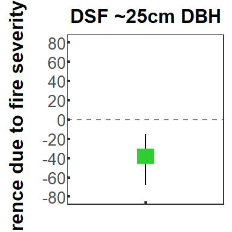

```r
My_Theme = theme(
  plot.title = element_text(size = 12, face = "bold", hjust = 0.5),
  axis.title.y = element_text(size = 12, face = "bold"),
  axis.text.y = element_text(size = 10, margin = unit(c(0.1, 0.1, 0.1, -0.2), "cm")),
  axis.text.x = element_blank(),
  axis.title.x = element_text(size = 12, face = "bold", vjust = -0.6),
  strip.text.x = element_text(size = 11),
  strip.text.y = element_text(size = 11),
  strip.text = element_text(size = 11),
  strip.background = element_blank(),
  panel.background = element_blank(),
  strip.placement = "inside",
  axis.ticks.length = unit(-0.07, "cm"),
  axis.ticks = element_line(size = 0.8),
  panel.grid.minor.x = element_blank(),
  panel.grid.major.x = element_blank(),
  panel.grid.minor.y = element_blank(),
  panel.grid.major.y = element_blank(),
  legend.position = "bottom",
  legend.title = element_text(size = 9, hjust = 0.6, face = "bold"),
  legend.text = element_text(size = 9),
  legend.key.width = unit(0.3, "cm"),
  legend.key.height = unit(0.5, "cm"),
  legend.background = element_blank(),
  plot.margin = unit(c(5, 5, 5, 5), "pt"))


diff.avg.frax3 <- ggplot(data = x.stats3.a.avg1, aes(x = var)) +

  My_Theme +

  geom_linerange(aes(ymin = lwr95, ymax = upr95),
               size = 0.5, position = position_dodge(width = 0.6)) +

  geom_linerange(aes(ymin = lwr50, ymax = upr50),
               size = 5.0, show.legend = FALSE, position = position_dodge(width = 0.6), col = "limegreen") +


  labs(x = "", y = "Difference due to fire severity (%)\n", title = "DSF ~25cm DBH") +


  geom_hline(yintercept = 0, linetype = "dashed", alpha = 0.5) +


  scale_y_continuous(labels = scales::percent_format(suffix = "", accuracy = 1), limits = c(-0.8, 0.8), breaks = c(-0.8, -0.6, -0.4, -0.2, 0, 0.2, 0.4, 0.6, 0.8)) +
  coord_cartesian(ylim=c(-0.8, 0.8))

diff.avg.frax3
```

## Change in difference for 25 cm trees

```r
dat.gg3.a.avg1 %>%
  group_by(var) %>%
  summarize(prob = mean(diff))
```

|  | var | prob |
| --- | --- | --- |
| 1 | sev | -0.1028085 |

Summary of magnitude of differences based on 50% and 95% highest posterior density intervals for 25cm trees

```r
x.stats3.a.avg1
```

|  | var | mid | lwr95 | upr95 | lwr50 | upr50 |
| --- | --- | --- | --- | --- | --- | --- |
| 1 | sev | -0.389769 | -0.6761392 | -0.1498418 | -0.4614811 | -0.3036654 |

### difference for larger trees Low- High

```r
My_Theme = theme(
  plot.title = element_text(size = 12, face = "bold", hjust = 0.5),
  axis.title.y = element_text(size = 12, face = "bold"),
  axis.text.y = element_text(size = 10, margin = unit(c(0.1, 0.1, 0.1, -0.2), "cm")),
  axis.text.x = element_blank(),
  axis.title.x = element_text(size = 12, face = "bold", vjust = -0.6),
  strip.text.x = element_text(size = 11),
  strip.text.y = element_text(size = 11),
  strip.text = element_text(size = 11),
  strip.background = element_blank(),
  panel.background = element_blank(),
  strip.placement = "inside",
  axis.ticks.length = unit(-0.07, "cm"),
  axis.ticks = element_line(size = 0.8),
  panel.grid.minor.x = element_blank(),
  panel.grid.major.x = element_blank(),
  panel.grid.minor.y = element_blank(),
  panel.grid.major.y = element_blank(),
  legend.position = "bottom",
  legend.title = element_text(size = 9, hjust = 0.6, face = "bold"),
  legend.text = element_text(size = 9),
  legend.key.width = unit(0.3, "cm"),
  legend.key.height = unit(0.5, "cm"),
  legend.background = element_blank(),
  plot.margin = unit(c(5, 5, 5, 5), "pt"))


diff.lrg.frax <- ggplot(data = x.stats1.a.lrg1, aes(x = var)) +

  My_Theme +

  geom_linerange(aes(ymin = lwr95, ymax = upr95),
               size = 0.5, position = position_dodge(width = 0.6)) +

  geom_linerange(aes(ymin = lwr50, ymax = upr50),
               size = 5.0, show.legend = FALSE, position = position_dodge(width = 0.6), col = "limegreen") +


  labs(x = "", y = "Difference due to fire severity (%)\n", title = "DSF ~50cm DBH") +


  geom_hline(yintercept = 0, linetype = "dashed", alpha = 0.5) +

### remeber to check what the actual numbers are before you rescale the plot in this bit, because if the numbers fall outside of the specifications here then it might not show anything
  scale_y_continuous(labels = scales::percent_format(suffix = "", accuracy = 1), limits = c(-1, 1), breaks = c(-1, -0.8, -0.6, -0.4, -0.2, 0, 0.2, 0.4, 0.6, 0.8, 1))
  coord_cartesian(ylim=c(-1, 1))
```

[output not shown]

```r
diff.lrg.frax
```

[output not shown]

Change in difference for 50 cm trees

```r
dat.gg1.a.lrg1 %>%
  group_by(var) %>%
  summarize(prob = mean(diff))
```

|  | var | prob |
| --- | --- | --- |
| 1 | sev | -0.7109607 |

```r
x.stats1.a.lrg1
```

|  | var | mid | lwr95 | upr95 | lwr50 | upr50 |
| --- | --- | --- | --- | --- | --- | --- |
| 1 | sev | -0.7177384 | -0.9091707 | -0.4880436 | -0.7875859 | -0.659075 |

### difference for larger trees Low- Mod

```r
My_Theme = theme(
  plot.title = element_text(size = 12, face = "bold", hjust = 0.5),
  axis.title.y = element_text(size = 12, face = "bold"),
  axis.text.y = element_text(size = 10, margin = unit(c(0.1, 0.1, 0.1, -0.2), "cm")),
  axis.text.x = element_blank(),
  axis.title.x = element_text(size = 12, face = "bold", vjust = -0.6),
  strip.text.x = element_text(size = 11),
  strip.text.y = element_text(size = 11),
  strip.text = element_text(size = 11),
  strip.background = element_blank(),
  panel.background = element_blank(),
  strip.placement = "inside",
  axis.ticks.length = unit(-0.07, "cm"),
  axis.ticks = element_line(size = 0.8),
  panel.grid.minor.x = element_blank(),
  panel.grid.major.x = element_blank(),
  panel.grid.minor.y = element_blank(),
  panel.grid.major.y = element_blank(),
  legend.position = "bottom",
  legend.title = element_text(size = 9, hjust = 0.6, face = "bold"),
  legend.text = element_text(size = 9),
  legend.key.width = unit(0.3, "cm"),
  legend.key.height = unit(0.5, "cm"),
  legend.background = element_blank(),
  plot.margin = unit(c(5, 5, 5, 5), "pt"))


diff.lrg.frax2 <- ggplot(data = x.stats2.a.lrg1, aes(x = var)) +

  My_Theme +

  geom_linerange(aes(ymin = lwr95, ymax = upr95),
               size = 0.5, position = position_dodge(width = 0.6)) +

  geom_linerange(aes(ymin = lwr50, ymax = upr50),
               size = 5.0, show.legend = FALSE, position = position_dodge(width = 0.6), col = "limegreen") +


  labs(x = "", y = "Difference due to fire severity (%)\n", title = "DSF ~50cm DBH") +


  geom_hline(yintercept = 0, linetype = "dashed", alpha = 0.5) +

### remeber to check what the actual numbers are before you rescale the plot in this bit, because if the numbers fall outside of the specifications here then it might not show anything
  scale_y_continuous(labels = scales::percent_format(suffix = "", accuracy = 1), limits = c(-1, 1), breaks = c(-1, -0.8, -0.6, -0.4, -0.2, 0, 0.2, 0.4, 0.6, 0.8, 1))
  coord_cartesian(ylim=c(-1, 1))
```

[output not shown]

```r
diff.lrg.frax2
```

[output not shown]

Change in difference for 50 cm trees

```r
dat.gg2.a.lrg1 %>%
  group_by(var) %>%
  summarize(prob = mean(diff))
```

|  | var | prob |
| --- | --- | --- |
| 1 | sev | -0.4112942 |

```r
x.stats2.a.lrg1
```

|  | var | mid | lwr95 | upr95 | lwr50 | upr50 |
| --- | --- | --- | --- | --- | --- | --- |
| 1 | sev | -0.7177384 | -0.9091707 | -0.4880436 | -0.7875859 | -0.659075 |

### difference for larger trees Mod - High

```r
My_Theme = theme(
  plot.title = element_text(size = 12, face = "bold", hjust = 0.5),
  axis.title.y = element_text(size = 12, face = "bold"),
  axis.text.y = element_text(size = 10, margin = unit(c(0.1, 0.1, 0.1, -0.2), "cm")),
  axis.text.x = element_blank(),
  axis.title.x = element_text(size = 12, face = "bold", vjust = -0.6),
  strip.text.x = element_text(size = 11),
  strip.text.y = element_text(size = 11),
  strip.text = element_text(size = 11),
  strip.background = element_blank(),
  panel.background = element_blank(),
  strip.placement = "inside",
  axis.ticks.length = unit(-0.07, "cm"),
  axis.ticks = element_line(size = 0.8),
  panel.grid.minor.x = element_blank(),
  panel.grid.major.x = element_blank(),
  panel.grid.minor.y = element_blank(),
  panel.grid.major.y = element_blank(),
  legend.position = "bottom",
  legend.title = element_text(size = 9, hjust = 0.6, face = "bold"),
  legend.text = element_text(size = 9),
  legend.key.width = unit(0.3, "cm"),
  legend.key.height = unit(0.5, "cm"),
  legend.background = element_blank(),
  plot.margin = unit(c(5, 5, 5, 5), "pt"))


diff.lrg.frax3 <- ggplot(data = x.stats3.a.lrg1, aes(x = var)) +

  My_Theme +

  geom_linerange(aes(ymin = lwr95, ymax = upr95),
               size = 0.5, position = position_dodge(width = 0.6)) +

  geom_linerange(aes(ymin = lwr50, ymax = upr50),
               size = 5.0, show.legend = FALSE, position = position_dodge(width = 0.6), col = "limegreen") +


  labs(x = "", y = "Difference due to fire severity (%)\n", title = "DSF ~50cm DBH") +


  geom_hline(yintercept = 0, linetype = "dashed", alpha = 0.5) +

### remeber to check what the actual numbers are before you rescale the plot in this bit, because if the numbers fall outside of the specifications here then it might not show anything
  scale_y_continuous(labels = scales::percent_format(suffix = "", accuracy = 1), limits = c(-1, 1), breaks = c(-1, -0.8, -0.6, -0.4, -0.2, 0, 0.2, 0.4, 0.6, 0.8, 1))
  coord_cartesian(ylim=c(-1, 1))
```

[output not shown]

```r
diff.lrg.frax3
```

[output not shown]

Change in difference for 50 cm trees

```r
dat.gg3.a.lrg1 %>%
  group_by(var) %>%
  summarize(prob = mean(diff))
```

|  | var | prob |
| --- | --- | --- |
| 1 | sev | -0.2996665 |

```r
x.stats3.a.lrg1
```

|  | var | mid | lwr95 | upr95 | lwr50 | upr50 |
| --- | --- | --- | --- | --- | --- | --- |
| 1 | sev | -0.7177384 | -0.9091707 | -0.4880436 | -0.7875859 | -0.659075 |